# Risk Factor Analysis

## Outcome Variable

**Outcome Variable:** ever_swasted

## Predictor Variables

**Intervention Variable:** hdlvry

**Adjustment Set:**

unadjusted

## Stratifying Variables

The analysis was stratified on these variable(s):

- agecat
- studyid
- country

## Data Summary

| agecat | studyid | country | hdlvry | ever_swasted | n_cell | n |
| --- | --- | --- | --- | --- | --- | --- |
| 0-24 months (no birth wast) | CMC-V-BCS-2002 | INDIA | 0 | 0 | 303 | 365 |
| 0-24 months (no birth wast) | CMC-V-BCS-2002 | INDIA | 0 | 1 | 54 | 365 |
| 0-24 months (no birth wast) | CMC-V-BCS-2002 | INDIA | 1 | 0 | 7 | 365 |
| 0-24 months (no birth wast) | CMC-V-BCS-2002 | INDIA | 1 | 1 | 1 | 365 |
| 0-24 months (no birth wast) | COHORTS | INDIA | 0 | 0 | 2916 | 4904 |
| 0-24 months (no birth wast) | COHORTS | INDIA | 0 | 1 | 114 | 4904 |
| 0-24 months (no birth wast) | COHORTS | INDIA | 1 | 0 | 1743 | 4904 |
| 0-24 months (no birth wast) | COHORTS | INDIA | 1 | 1 | 131 | 4904 |
| 0-24 months (no birth wast) | EE | PAKISTAN | 0 | 0 | 210 | 375 |
| 0-24 months (no birth wast) | EE | PAKISTAN | 0 | 1 | 42 | 375 |
| 0-24 months (no birth wast) | EE | PAKISTAN | 1 | 0 | 100 | 375 |
| 0-24 months (no birth wast) | EE | PAKISTAN | 1 | 1 | 23 | 375 |
| 0-24 months (no birth wast) | GMS-Nepal | NEPAL | 0 | 0 | 132 | 613 |
| 0-24 months (no birth wast) | GMS-Nepal | NEPAL | 0 | 1 | 16 | 613 |
| 0-24 months (no birth wast) | GMS-Nepal | NEPAL | 1 | 0 | 361 | 613 |
| 0-24 months (no birth wast) | GMS-Nepal | NEPAL | 1 | 1 | 104 | 613 |
| 0-24 months (no birth wast) | IRC | INDIA | 0 | 0 | 326 | 409 |
| 0-24 months (no birth wast) | IRC | INDIA | 0 | 1 | 75 | 409 |
| 0-24 months (no birth wast) | IRC | INDIA | 1 | 0 | 6 | 409 |
| 0-24 months (no birth wast) | IRC | INDIA | 1 | 1 | 2 | 409 |
| 0-24 months (no birth wast) | NIH-Crypto | BANGLADESH | 0 | 0 | 573 | 754 |
| 0-24 months (no birth wast) | NIH-Crypto | BANGLADESH | 0 | 1 | 14 | 754 |
| 0-24 months (no birth wast) | NIH-Crypto | BANGLADESH | 1 | 0 | 161 | 754 |
| 0-24 months (no birth wast) | NIH-Crypto | BANGLADESH | 1 | 1 | 6 | 754 |
| 0-24 months (no birth wast) | PROVIDE | BANGLADESH | 0 | 0 | 500 | 687 |
| 0-24 months (no birth wast) | PROVIDE | BANGLADESH | 0 | 1 | 13 | 687 |
| 0-24 months (no birth wast) | PROVIDE | BANGLADESH | 1 | 0 | 168 | 687 |
| 0-24 months (no birth wast) | PROVIDE | BANGLADESH | 1 | 1 | 6 | 687 |
| 0-24 months (no birth wast) | SAS-CompFeed | INDIA | 0 | 0 | 151 | 1224 |
| 0-24 months (no birth wast) | SAS-CompFeed | INDIA | 0 | 1 | 13 | 1224 |

[output cut: 90 more lines]

The following strata were considered:

- agecat: 0-24 months (no birth wast), studyid: CMC-V-BCS-2002, country: INDIA
- agecat: 0-24 months (no birth wast), studyid: COHORTS, country: INDIA
- agecat: 0-24 months (no birth wast), studyid: EE, country: PAKISTAN
- agecat: 0-24 months (no birth wast), studyid: GMS-Nepal, country: NEPAL
- agecat: 0-24 months (no birth wast), studyid: IRC, country: INDIA
- agecat: 0-24 months (no birth wast), studyid: NIH-Crypto, country: BANGLADESH
- agecat: 0-24 months (no birth wast), studyid: PROVIDE, country: BANGLADESH
- agecat: 0-24 months (no birth wast), studyid: SAS-CompFeed, country: INDIA
- agecat: 0-24 months (no birth wast), studyid: SAS-FoodSuppl, country: INDIA
- agecat: 0-24 months (no birth wast), studyid: TanzaniaChild2, country: TANZANIA, UNITED REPUBLIC OF
- agecat: 0-6 months (no birth wast), studyid: CMC-V-BCS-2002, country: INDIA
- agecat: 0-6 months (no birth wast), studyid: COHORTS, country: INDIA
- agecat: 0-6 months (no birth wast), studyid: EE, country: PAKISTAN
- agecat: 0-6 months (no birth wast), studyid: GMS-Nepal, country: NEPAL
- agecat: 0-6 months (no birth wast), studyid: IRC, country: INDIA
- agecat: 0-6 months (no birth wast), studyid: NIH-Crypto, country: BANGLADESH
- agecat: 0-6 months (no birth wast), studyid: PROVIDE, country: BANGLADESH
- agecat: 0-6 months (no birth wast), studyid: SAS-CompFeed, country: INDIA
- agecat: 0-6 months (no birth wast), studyid: SAS-FoodSuppl, country: INDIA
- agecat: 0-6 months (no birth wast), studyid: TanzaniaChild2, country: TANZANIA, UNITED REPUBLIC OF
- agecat: 6-24 months, studyid: CMC-V-BCS-2002, country: INDIA
- agecat: 6-24 months, studyid: COHORTS, country: INDIA
- agecat: 6-24 months, studyid: EE, country: PAKISTAN
- agecat: 6-24 months, studyid: GMS-Nepal, country: NEPAL
- agecat: 6-24 months, studyid: IRC, country: INDIA
- agecat: 6-24 months, studyid: NIH-Crypto, country: BANGLADESH
- agecat: 6-24 months, studyid: PROVIDE, country: BANGLADESH
- agecat: 6-24 months, studyid: SAS-CompFeed, country: INDIA
- agecat: 6-24 months, studyid: SAS-FoodSuppl, country: INDIA
- agecat: 6-24 months, studyid: TanzaniaChild2, country: TANZANIA, UNITED REPUBLIC OF

### Dropped Strata

Some strata were dropped due to rare outcomes:

- agecat: 0-24 months (no birth wast), studyid: CMC-V-BCS-2002, country: INDIA
- agecat: 0-24 months (no birth wast), studyid: IRC, country: INDIA
- agecat: 0-24 months (no birth wast), studyid: TanzaniaChild2, country: TANZANIA, UNITED REPUBLIC OF
- agecat: 0-6 months (no birth wast), studyid: CMC-V-BCS-2002, country: INDIA
- agecat: 0-6 months (no birth wast), studyid: IRC, country: INDIA
- agecat: 0-6 months (no birth wast), studyid: NIH-Crypto, country: BANGLADESH
- agecat: 0-6 months (no birth wast), studyid: PROVIDE, country: BANGLADESH
- agecat: 0-6 months (no birth wast), studyid: SAS-CompFeed, country: INDIA
- agecat: 0-6 months (no birth wast), studyid: SAS-FoodSuppl, country: INDIA
- agecat: 0-6 months (no birth wast), studyid: TanzaniaChild2, country: TANZANIA, UNITED REPUBLIC OF
- agecat: 6-24 months, studyid: CMC-V-BCS-2002, country: INDIA
- agecat: 6-24 months, studyid: IRC, country: INDIA
- agecat: 6-24 months, studyid: TanzaniaChild2, country: TANZANIA, UNITED REPUBLIC OF

## Methods Detail

We’re interested in the causal parameters $E[Y_a]$ for all values of $a \in \mathcal{A}$. These parameters represent the mean outcome if, possibly contrary to fact, we intervened to set all units to have $A=a$. Under the randomization and positivity assumptions, these are identified by the statistical parameters $\psi_a=E_W[E_{Y|A,W}(Y|A=a,W)]$. In addition, we’re interested in the mean of $Y$, $E[Y]$ under no intervention (the observed mean). We will estimate these parameters by using SuperLearner to fit the relevant likelihood factors – $E_{Y|A,W}(Y|A=a,W)$ and $p(A=a|W)$, and then updating our likelihood fit using a joint TMLE.

For unadjusted analyses ($W=\{\}$), initial likelihoods were estimated using Lrnr_glm to estimate the simple $E(Y|A)$ and Lrnr_mean to estimate $p(A)$. For adjusted analyses, a small library containing Lrnr_glmnet, Lrnr_xgboost, and Lrnr_mean was used.

Having estimated these parameters, we will then use the delta method to estimate relative risks and attributable risks relative to a prespecified baseline level of $A$.

# Results Detail

## Results Plots

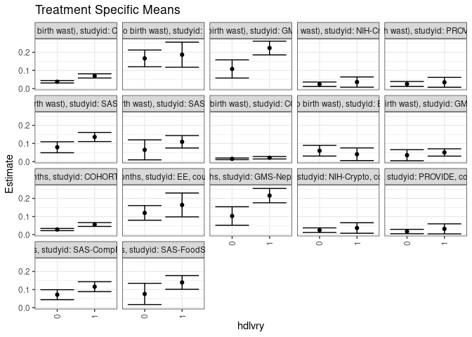

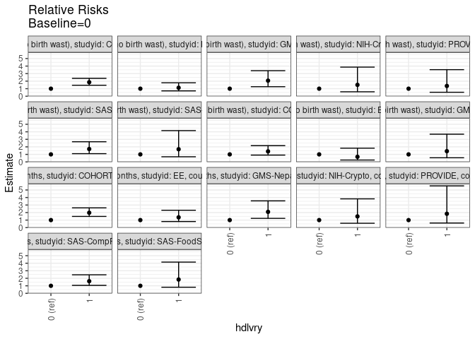

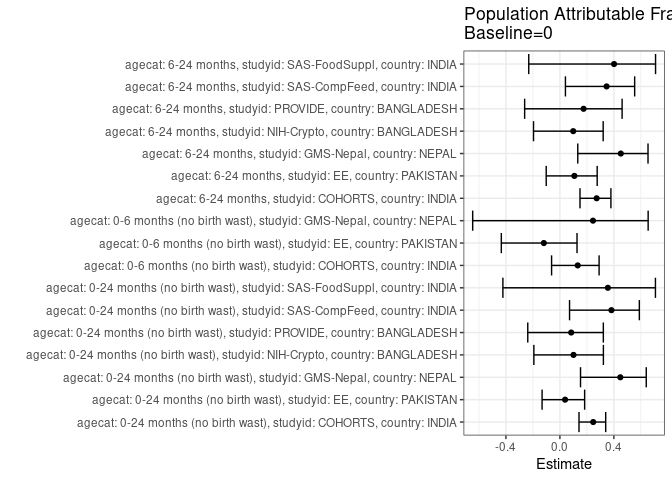

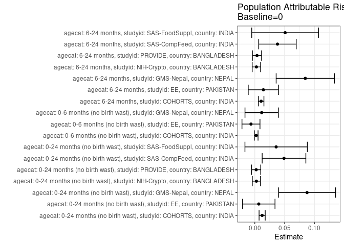

## Results Table

### Parameter: TSM

| agecat | studyid | country | intervention_level | baseline_level | estimate | ci_lower | ci_upper |
| --- | --- | --- | --- | --- | --- | --- | --- |
| 0-24 months (no birth wast) | COHORTS | INDIA | 0 | NA | 0.0376238 | 0.0308477 | 0.0443998 |
| 0-24 months (no birth wast) | COHORTS | INDIA | 1 | NA | 0.0699039 | 0.0583582 | 0.0814497 |
| 0-24 months (no birth wast) | EE | PAKISTAN | 0 | NA | 0.1666667 | 0.1205921 | 0.2127412 |
| 0-24 months (no birth wast) | EE | PAKISTAN | 1 | NA | 0.1869919 | 0.1179942 | 0.2559895 |
| 0-24 months (no birth wast) | GMS-Nepal | NEPAL | 0 | NA | 0.1081081 | 0.0580405 | 0.1581757 |
| 0-24 months (no birth wast) | GMS-Nepal | NEPAL | 1 | NA | 0.2236559 | 0.1857512 | 0.2615606 |
| 0-24 months (no birth wast) | NIH-Crypto | BANGLADESH | 0 | NA | 0.0238501 | 0.0114986 | 0.0362016 |
| 0-24 months (no birth wast) | NIH-Crypto | BANGLADESH | 1 | NA | 0.0359281 | 0.0076826 | 0.0641737 |
| 0-24 months (no birth wast) | PROVIDE | BANGLADESH | 0 | NA | 0.0253411 | 0.0117315 | 0.0389507 |
| 0-24 months (no birth wast) | PROVIDE | BANGLADESH | 1 | NA | 0.0344828 | 0.0073514 | 0.0616141 |
| 0-24 months (no birth wast) | SAS-CompFeed | INDIA | 0 | NA | 0.0792683 | 0.0490080 | 0.1095286 |
| 0-24 months (no birth wast) | SAS-CompFeed | INDIA | 1 | NA | 0.1358491 | 0.1107027 | 0.1609954 |
| 0-24 months (no birth wast) | SAS-FoodSuppl | INDIA | 0 | NA | 0.0649351 | 0.0098275 | 0.1200426 |
| 0-24 months (no birth wast) | SAS-FoodSuppl | INDIA | 1 | NA | 0.1093750 | 0.0751355 | 0.1436145 |
| 0-6 months (no birth wast) | COHORTS | INDIA | 0 | NA | 0.0153407 | 0.0107903 | 0.0198911 |
| 0-6 months (no birth wast) | COHORTS | INDIA | 1 | NA | 0.0214742 | 0.0146288 | 0.0283196 |
| 0-6 months (no birth wast) | EE | PAKISTAN | 0 | NA | 0.0600000 | 0.0305218 | 0.0894782 |
| 0-6 months (no birth wast) | EE | PAKISTAN | 1 | NA | 0.0406504 | 0.0057043 | 0.0755966 |
| 0-6 months (no birth wast) | GMS-Nepal | NEPAL | 0 | NA | 0.0354610 | 0.0049091 | 0.0660129 |
| 0-6 months (no birth wast) | GMS-Nepal | NEPAL | 1 | NA | 0.0505495 | 0.0304029 | 0.0706960 |
| 6-24 months | COHORTS | INDIA | 0 | NA | 0.0283858 | 0.0223657 | 0.0344059 |
| 6-24 months | COHORTS | INDIA | 1 | NA | 0.0561056 | 0.0455262 | 0.0666850 |
| 6-24 months | EE | PAKISTAN | 0 | NA | 0.1200000 | 0.0796638 | 0.1603362 |
| 6-24 months | EE | PAKISTAN | 1 | NA | 0.1639344 | 0.0981523 | 0.2297166 |
| 6-24 months | GMS-Nepal | NEPAL | 0 | NA | 0.1029412 | 0.0518225 | 0.1540598 |
| 6-24 months | GMS-Nepal | NEPAL | 1 | NA | 0.2154964 | 0.1758059 | 0.2551869 |
| 6-24 months | NIH-Crypto | BANGLADESH | 0 | NA | 0.0246914 | 0.0119094 | 0.0374733 |
| 6-24 months | NIH-Crypto | BANGLADESH | 1 | NA | 0.0368098 | 0.0078837 | 0.0657359 |
| 6-24 months | PROVIDE | BANGLADESH | 0 | NA | 0.0174292 | 0.0054476 | 0.0294108 |
| 6-24 months | PROVIDE | BANGLADESH | 1 | NA | 0.0320513 | 0.0043890 | 0.0597136 |
| 6-24 months | SAS-CompFeed | INDIA | 0 | NA | 0.0718954 | 0.0444581 | 0.0993328 |
| 6-24 months | SAS-CompFeed | INDIA | 1 | NA | 0.1158974 | 0.0885815 | 0.1432134 |
| 6-24 months | SAS-FoodSuppl | INDIA | 0 | NA | 0.0759494 | 0.0174589 | 0.1344399 |
| 6-24 months | SAS-FoodSuppl | INDIA | 1 | NA | 0.1393189 | 0.1015083 | 0.1771295 |

### Parameter: E(Y)

| agecat | studyid | country | intervention_level | baseline_level | estimate | ci_lower | ci_upper |
| --- | --- | --- | --- | --- | --- | --- | --- |
| 0-24 months (no birth wast) | COHORTS | INDIA | NA | NA | 0.0499592 | 0.0438611 | 0.0560573 |
| 0-24 months (no birth wast) | EE | PAKISTAN | NA | NA | 0.1733333 | 0.1349698 | 0.2116969 |
| 0-24 months (no birth wast) | GMS-Nepal | NEPAL | NA | NA | 0.1957586 | 0.1643227 | 0.2271945 |
| 0-24 months (no birth wast) | NIH-Crypto | BANGLADESH | NA | NA | 0.0265252 | 0.0150478 | 0.0380026 |
| 0-24 months (no birth wast) | PROVIDE | BANGLADESH | NA | NA | 0.0276565 | 0.0153851 | 0.0399279 |
| 0-24 months (no birth wast) | SAS-CompFeed | INDIA | NA | NA | 0.1282680 | 0.1041743 | 0.1523617 |
| 0-24 months (no birth wast) | SAS-FoodSuppl | INDIA | NA | NA | 0.1007557 | 0.0711091 | 0.1304022 |
| 0-6 months (no birth wast) | COHORTS | INDIA | NA | NA | 0.0176757 | 0.0138363 | 0.0215150 |
| 0-6 months (no birth wast) | EE | PAKISTAN | NA | NA | 0.0536193 | 0.0307280 | 0.0765106 |
| 0-6 months (no birth wast) | GMS-Nepal | NEPAL | NA | NA | 0.0469799 | 0.0299780 | 0.0639817 |
| 6-24 months | COHORTS | INDIA | NA | NA | 0.0390131 | 0.0335015 | 0.0445247 |
| 6-24 months | EE | PAKISTAN | NA | NA | 0.1344086 | 0.0997005 | 0.1691167 |
| 6-24 months | GMS-Nepal | NEPAL | NA | NA | 0.1876138 | 0.1549271 | 0.2203006 |
| 6-24 months | NIH-Crypto | BANGLADESH | NA | NA | 0.0273973 | 0.0155476 | 0.0392469 |
| 6-24 months | PROVIDE | BANGLADESH | NA | NA | 0.0211382 | 0.0097604 | 0.0325160 |
| 6-24 months | SAS-CompFeed | INDIA | NA | NA | 0.1099291 | 0.0842813 | 0.1355769 |
| 6-24 months | SAS-FoodSuppl | INDIA | NA | NA | 0.1268657 | 0.0942904 | 0.1594410 |

### Parameter: RR

| agecat | studyid | country | intervention_level | baseline_level | estimate | ci_lower | ci_upper |
| --- | --- | --- | --- | --- | --- | --- | --- |
| 0-24 months (no birth wast) | COHORTS | INDIA | 0 | 0 | 1.0000000 | 1.0000000 | 1.000000 |
| 0-24 months (no birth wast) | COHORTS | INDIA | 1 | 0 | 1.8579734 | 1.4551639 | 2.372286 |
| 0-24 months (no birth wast) | EE | PAKISTAN | 0 | 0 | 1.0000000 | 1.0000000 | 1.000000 |
| 0-24 months (no birth wast) | EE | PAKISTAN | 1 | 0 | 1.1219512 | 0.7075202 | 1.779136 |
| 0-24 months (no birth wast) | GMS-Nepal | NEPAL | 0 | 0 | 1.0000000 | 1.0000000 | 1.000000 |
| 0-24 months (no birth wast) | GMS-Nepal | NEPAL | 1 | 0 | 2.0688172 | 1.2634117 | 3.387656 |
| 0-24 months (no birth wast) | NIH-Crypto | BANGLADESH | 0 | 0 | 1.0000000 | 1.0000000 | 1.000000 |
| 0-24 months (no birth wast) | NIH-Crypto | BANGLADESH | 1 | 0 | 1.5064157 | 0.5876161 | 3.861855 |
| 0-24 months (no birth wast) | PROVIDE | BANGLADESH | 0 | 0 | 1.0000000 | 1.0000000 | 1.000000 |
| 0-24 months (no birth wast) | PROVIDE | BANGLADESH | 1 | 0 | 1.3607427 | 0.5248752 | 3.527735 |
| 0-24 months (no birth wast) | SAS-CompFeed | INDIA | 0 | 0 | 1.0000000 | 1.0000000 | 1.000000 |
| 0-24 months (no birth wast) | SAS-CompFeed | INDIA | 1 | 0 | 1.7137881 | 1.0962953 | 2.679086 |
| 0-24 months (no birth wast) | SAS-FoodSuppl | INDIA | 0 | 0 | 1.0000000 | 1.0000000 | 1.000000 |
| 0-24 months (no birth wast) | SAS-FoodSuppl | INDIA | 1 | 0 | 1.6843750 | 0.6817053 | 4.161797 |
| 0-6 months (no birth wast) | COHORTS | INDIA | 0 | 0 | 1.0000000 | 1.0000000 | 1.000000 |
| 0-6 months (no birth wast) | COHORTS | INDIA | 1 | 0 | 1.3998164 | 0.9056600 | 2.163600 |
| 0-6 months (no birth wast) | EE | PAKISTAN | 0 | 0 | 1.0000000 | 1.0000000 | 1.000000 |
| 0-6 months (no birth wast) | EE | PAKISTAN | 1 | 0 | 0.6775068 | 0.2517050 | 1.823624 |
| 0-6 months (no birth wast) | GMS-Nepal | NEPAL | 0 | 0 | 1.0000000 | 1.0000000 | 1.000000 |
| 0-6 months (no birth wast) | GMS-Nepal | NEPAL | 1 | 0 | 1.4254945 | 0.5516931 | 3.683270 |
| 6-24 months | COHORTS | INDIA | 0 | 0 | 1.0000000 | 1.0000000 | 1.000000 |
| 6-24 months | COHORTS | INDIA | 1 | 0 | 1.9765398 | 1.4881925 | 2.625137 |
| 6-24 months | EE | PAKISTAN | 0 | 0 | 1.0000000 | 1.0000000 | 1.000000 |
| 6-24 months | EE | PAKISTAN | 1 | 0 | 1.3661202 | 0.8093854 | 2.305804 |
| 6-24 months | GMS-Nepal | NEPAL | 0 | 0 | 1.0000000 | 1.0000000 | 1.000000 |
| 6-24 months | GMS-Nepal | NEPAL | 1 | 0 | 2.0933933 | 1.2326284 | 3.555245 |
| 6-24 months | NIH-Crypto | BANGLADESH | 0 | 0 | 1.0000000 | 1.0000000 | 1.000000 |
| 6-24 months | NIH-Crypto | BANGLADESH | 1 | 0 | 1.4907975 | 0.5817579 | 3.820279 |
| 6-24 months | PROVIDE | BANGLADESH | 0 | 0 | 1.0000000 | 1.0000000 | 1.000000 |
| 6-24 months | PROVIDE | BANGLADESH | 1 | 0 | 1.8389423 | 0.6100618 | 5.543223 |
| 6-24 months | SAS-CompFeed | INDIA | 0 | 0 | 1.0000000 | 1.0000000 | 1.000000 |
| 6-24 months | SAS-CompFeed | INDIA | 1 | 0 | 1.6120280 | 1.0564375 | 2.459809 |
| 6-24 months | SAS-FoodSuppl | INDIA | 0 | 0 | 1.0000000 | 1.0000000 | 1.000000 |
| 6-24 months | SAS-FoodSuppl | INDIA | 1 | 0 | 1.8343653 | 0.8107074 | 4.150568 |

### Parameter: PAR

| agecat | studyid | country | intervention_level | baseline_level | estimate | ci_lower | ci_upper |
| --- | --- | --- | --- | --- | --- | --- | --- |
| 0-24 months (no birth wast) | COHORTS | INDIA | 0 | NA | 0.0123355 | 0.0072009 | 0.0174700 |
| 0-24 months (no birth wast) | EE | PAKISTAN | 0 | NA | 0.0066667 | -0.0205637 | 0.0338971 |
| 0-24 months (no birth wast) | GMS-Nepal | NEPAL | 0 | NA | 0.0876505 | 0.0398536 | 0.1354473 |
| 0-24 months (no birth wast) | NIH-Crypto | BANGLADESH | 0 | NA | 0.0026751 | -0.0041623 | 0.0095125 |
| 0-24 months (no birth wast) | PROVIDE | BANGLADESH | 0 | NA | 0.0023153 | -0.0053782 | 0.0100089 |
| 0-24 months (no birth wast) | SAS-CompFeed | INDIA | 0 | NA | 0.0489997 | 0.0123813 | 0.0856181 |
| 0-24 months (no birth wast) | SAS-FoodSuppl | INDIA | 0 | NA | 0.0358206 | -0.0165028 | 0.0881440 |
| 0-6 months (no birth wast) | COHORTS | INDIA | 0 | NA | 0.0023349 | -0.0007955 | 0.0054653 |
| 0-6 months (no birth wast) | EE | PAKISTAN | 0 | NA | -0.0063807 | -0.0214851 | 0.0087237 |
| 0-6 months (no birth wast) | GMS-Nepal | NEPAL | 0 | NA | 0.0115189 | -0.0164245 | 0.0394622 |
| 6-24 months | COHORTS | INDIA | 0 | NA | 0.0106273 | 0.0059449 | 0.0153097 |
| 6-24 months | EE | PAKISTAN | 0 | NA | 0.0144086 | -0.0109848 | 0.0398020 |
| 6-24 months | GMS-Nepal | NEPAL | 0 | NA | 0.0846727 | 0.0358169 | 0.1335284 |
| 6-24 months | NIH-Crypto | BANGLADESH | 0 | NA | 0.0027059 | -0.0043649 | 0.0097767 |
| 6-24 months | PROVIDE | BANGLADESH | 0 | NA | 0.0037090 | -0.0039542 | 0.0113723 |
| 6-24 months | SAS-CompFeed | INDIA | 0 | NA | 0.0380337 | 0.0066128 | 0.0694545 |
| 6-24 months | SAS-FoodSuppl | INDIA | 0 | NA | 0.0509163 | -0.0050985 | 0.1069311 |

### Parameter: PAF

| agecat | studyid | country | intervention_level | baseline_level | estimate | ci_lower | ci_upper |
| --- | --- | --- | --- | --- | --- | --- | --- |
| 0-24 months (no birth wast) | COHORTS | INDIA | 0 | NA | 0.2469105 | 0.1415390 | 0.3393482 |
| 0-24 months (no birth wast) | EE | PAKISTAN | 0 | NA | 0.0384615 | -0.1320367 | 0.1832807 |
| 0-24 months (no birth wast) | GMS-Nepal | NEPAL | 0 | NA | 0.4477477 | 0.1528484 | 0.6399906 |
| 0-24 months (no birth wast) | NIH-Crypto | BANGLADESH | 0 | NA | 0.1008518 | -0.1929625 | 0.3223027 |
| 0-24 months (no birth wast) | PROVIDE | BANGLADESH | 0 | NA | 0.0837181 | -0.2381152 | 0.3218946 |
| 0-24 months (no birth wast) | SAS-CompFeed | INDIA | 0 | NA | 0.3820103 | 0.0714875 | 0.5886848 |
| 0-24 months (no birth wast) | SAS-FoodSuppl | INDIA | 0 | NA | 0.3555195 | -0.4224191 | 0.7079938 |
| 0-6 months (no birth wast) | COHORTS | INDIA | 0 | NA | 0.1320995 | -0.0615914 | 0.2904509 |
| 0-6 months (no birth wast) | EE | PAKISTAN | 0 | NA | -0.1190000 | -0.4341545 | 0.1268995 |
| 0-6 months (no birth wast) | GMS-Nepal | NEPAL | 0 | NA | 0.2451874 | -0.6463468 | 0.6539356 |
| 6-24 months | COHORTS | INDIA | 0 | NA | 0.2724036 | 0.1489076 | 0.3779800 |
| 6-24 months | EE | PAKISTAN | 0 | NA | 0.1072000 | -0.1013874 | 0.2762839 |
| 6-24 months | GMS-Nepal | NEPAL | 0 | NA | 0.4513135 | 0.1324366 | 0.6529858 |
| 6-24 months | NIH-Crypto | BANGLADESH | 0 | NA | 0.0987654 | -0.1955788 | 0.3206439 |
| 6-24 months | PROVIDE | BANGLADESH | 0 | NA | 0.1754651 | -0.2612591 | 0.4609689 |
| 6-24 months | SAS-CompFeed | INDIA | 0 | NA | 0.3459836 | 0.0409931 | 0.5539787 |
| 6-24 months | SAS-FoodSuppl | INDIA | 0 | NA | 0.4013403 | -0.2308220 | 0.7088178 |